# Regression and Model Validation

*Describe the work you have done this week and summarize your learning.*

- Describe your work and results clearly.
- Assume the reader has an introductory course level understanding of writing and reading R code as well as statistical methods.
- Assume the reader has no previous knowledge of your data or the more advanced methods you are using.

The present chapter explores the dataset from the International Survey of Approaches to Learning. The data uses several variables to measure learning strategies and approaches, understanding and attitute of people towards statistics. This data will be further explained as we move forward in this chapter

```r
date()
```

```
## [1] "Sat Nov 11 13:05:55 2023"
```

# Chapter 2: Regression and Model Validation

The present chapter explores the dataset from the International Survey of Approaches to Learning. The data uses several variables to measure learning strategies and approaches, understanding and attitute of people towards statistics. This data will be further explained as we move forward in this chapter

## **Part 1: Data Wrangling**

## Reading data

Reading the table from the web read.table()only allows us to read the data. To be able to make changes to it, we need to store it in R. For this, we save it by the name “learn”

```r
options(repos = list(CRAN="http://cran.rstudio.com/"))
install.packages("DT")
learn <- read.table("http://www.helsinki.fi/~kvehkala/JYTmooc/JYTOPKYS3-data.txt", sep="\t", header=TRUE)
DT::datatable(learn, options = list(pageLength = 20))
```

|  | Aa | Ab | Ac | Ad | Ae | Af | ST01 | SU02 | D03 | ST04 | SU05 | D06 | D07 | SU08 | ST09 | SU10 | D11 | ST12 | SU13 | D14 | D15 | SU16 | ST17 | SU18 | D19 | ST20 | SU21 | D22 | D23 | … |
| --- | --- | --- | --- | --- | --- | --- | --- | --- | --- | --- | --- | --- | --- | --- | --- | --- | --- | --- | --- | --- | --- | --- | --- | --- | --- | --- | --- | --- | --- | --- |
| 1 | 3 | 1 | 2 | 1 | 1 | 1 | 4 | 2 | 4 | 4 | 2 | 4 | 4 | 3 | 3 | 2 | 3 | 3 | 3 | 4 | 3 | 2 | 3 | 2 | 4 | 2 | 3 | 3 | 2 | … |
| 2 | 2 | 2 | 2 | 2 | 1 | 1 | 4 | 2 | 4 | 4 | 4 | 2 | 3 | 4 | 4 | 1 | 4 | 1 | 3 | 2 | 3 | 4 | 4 | 2 | 3 | 1 | 2 | 2 | 3 | … |
| 3 | 4 | 1 | 1 | 1 | 1 | 1 | 3 | 1 | 4 | 4 | 2 | 3 | 4 | 1 | 3 | 1 | 4 | 4 | 2 | 4 | 2 | 3 | 3 | 1 | 4 | 3 | 2 | 4 | 3 | … |
| 4 | 4 | 2 | 3 | 2 | 1 | 1 | 3 | 3 | 4 | 4 | 3 | 4 | 4 | 2 | 3 | 1 | 3 | 3 | 2 | 4 | 3 | 2 | 3 | 1 | 3 | 3 | 3 | 3 | 3 | … |
| 5 | 3 | 2 | 2 | 1 | 2 | 1 | 4 | 2 | 5 | 3 | 4 | 4 | 4 | 3 | 4 | 2 | 4 | 2 | 3 | 4 | 3 | 3 | 4 | 1 | 4 | 3 | 2 | 3 | 3 | … |
| 6 | 4 | 2 | 1 | 1 | 1 | 1 | 4 | 3 | 5 | 4 | 3 | 5 | 5 | 4 | 4 | 1 | 5 | 3 | 1 | 5 | 4 | 2 | 3 | 2 | 4 | 3 | 4 | 5 | 4 | … |
| 7 | 4 | 1 | 2 | 2 | 1 | 1 | 5 | 2 | 4 | 2 | 2 | 3 | 4 | 4 | 2 | 1 | 5 | 2 | 1 | 5 | 2 | 3 | 4 | 1 | 4 | 1 | 1 | 4 | 3 | … |
| 8 | 3 | 1 | 2 | 1 | 1 | 1 | 4 | 2 | 4 | 5 | 4 | 3 | 4 | 2 | 4 | 2 | 3 | 4 | 2 | 4 | 2 | 3 | 3 | 2 | 4 | 4 | 3 | 2 | 2 | … |
| 9 | 2 | 1 | 2 | 1 | 1 | 1 | 4 | 1 | 5 | 5 | 2 | 4 | 5 | 4 | 4 | 1 | 4 | 4 | 1 | 4 | 3 | 4 | 4 | 1 | 5 | 4 | 2 | 4 | 4 | … |
| 10 | 3 | 2 | 1 | 1 | 1 | 2 | 4 | 2 | 4 | 4 | 4 | 4 | 4 | 2 | 4 | 2 | 4 | 4 | 2 | 4 | 4 | 4 | 4 | 2 | 4 | 2 | 4 | 4 | 4 | … |

[output cut: 173 more lines]

```r
# the DT package helps limit the table view to 20 rows at a time - it is a pretty large dataset
```

## Dimension and Structure of the dataset

### Dimensions of “learn”

```r
dim(learn)
```

```
## [1] 183  60
```

```r
#The table "learn" has 183 rows and 60 columns. However, this is also mentioned right below the table.
```

### Looking at the structure

```r
str(learn)
```

```
## 'data.frame':    183 obs. of  60 variables:
##  $ Aa      : int  3 2 4 4 3 4 4 3 2 3 ...
##  $ Ab      : int  1 2 1 2 2 2 1 1 1 2 ...
##  $ Ac      : int  2 2 1 3 2 1 2 2 2 1 ...
##  $ Ad      : int  1 2 1 2 1 1 2 1 1 1 ...
##  $ Ae      : int  1 1 1 1 2 1 1 1 1 1 ...
##  $ Af      : int  1 1 1 1 1 1 1 1 1 2 ...
##  $ ST01    : int  4 4 3 3 4 4 5 4 4 4 ...
##  $ SU02    : int  2 2 1 3 2 3 2 2 1 2 ...
##  $ D03     : int  4 4 4 4 5 5 4 4 5 4 ...
##  $ ST04    : int  4 4 4 4 3 4 2 5 5 4 ...
##  $ SU05    : int  2 4 2 3 4 3 2 4 2 4 ...
##  $ D06     : int  4 2 3 4 4 5 3 3 4 4 ...
##  $ D07     : int  4 3 4 4 4 5 4 4 5 4 ...
##  $ SU08    : int  3 4 1 2 3 4 4 2 4 2 ...
```

[output cut: 46 more lines]

```r
# All variables of integer type, except for gender, which is a character type
```

## Creating an Analysis dataset

As previosly mentioned,this dataset records variables to assess learning, understanding and attitudes of people towards statistics. The next steps take a look at some of these variables, namely

- Attitude: Global attitude toward statistics
- Deep: Deep approach to learning, which involves gaining an in-depth understanding
- Surf: Surface approach, consisting primarily of memorizing without understanding
- Stra: Strategic approach, which students apply in the face of constraints such as deadlines and syllabus

### 1. Scaling vectors to their original values:

Now, to create an analysis dataset, we need to keep in mind that some parameters are aggregates of two or more variables. These are:

1. Attitude = Da + Db + Dc + Dd + De + Df + Dg + Dh + Di + Dj
2. **Deep = d_sm + d_ri + d_ue**, and
- d_sm = D03 + D11 + D19 + D27
- d_ri = D07 + D14 + D22 + D30
- d_ue = D06 + D15 + D23 + D31
3. **Stra = st_os + st_tm**, where
- st_os = ST01 + ST09 + ST17 + ST25
- st_tm = ST04 + ST12 + ST20 + ST28
4. **Surf = su_lp + su_um + su_sb**, where
- su_lp = SU02 + SU10 + SU18 + SU26
- su_um = SU05 + SU13 + SU21 + SU29
- su_sb = SU08 + SU16 + SU24 + SU32

In order to **scale** Attitude, we need to divide it by the number of variables that constitute it.This is easily done by creating a new variable and assigning the new value to it

Hence,

```r
# divide each number in the column "Attitude" by 10

# create column 'attitude' by scaling the column "Attitude"
learn$attitude <- learn$Attitude / 10
```

Now for the other variables, since “deep”, “Surf” and “stra” do not exist in this dataset, we must create them by aggregating and averaging their constituents

*But first, lemme access the dplyr library*

```r
library(dplyr)
# questions related to deep, surface and strategic learning
deep_questions <- c("D03", "D11", "D19", "D27", "D07", "D14", "D22", "D30","D06",  "D15", "D23", "D31")
surface_questions <- c("SU02","SU10","SU18","SU26", "SU05","SU13","SU21","SU29","SU08","SU16","SU24","SU32")
strategic_questions <- c("ST01","ST09","ST17","ST25","ST04","ST12","ST20","ST28")

# select the columns related to deep learning
deep_columns <- select(learn, one_of(deep_questions))
# and create column 'deep' by averaging
learn$deep <- rowMeans(deep_columns)

# select the columns related to surface learning
surface_columns <- select(learn, one_of(surface_questions))
# and create column 'surf' by averaging
learn$surf <- rowMeans(surface_columns)

# select the columns related to strategic learning
strategic_columns <- select(learn, one_of(strategic_questions))
# and create column 'stra' by averaging
learn$stra <- rowMeans(strategic_columns)
# and create column 'stra' by averaging
```

Now these columns can be extracted from the original table and made into a table of their own, as it makes working with the data easier.

[output not shown]

```r
# veiw the columns
learn$deep
```

```
##   [1] 3.583333 2.916667 3.500000 3.500000 3.666667 4.750000 3.833333 3.250000
##   [9] 4.333333 4.000000 3.583333 3.833333 4.250000 3.333333 4.166667 3.083333
##  [17] 3.666667 4.083333 3.500000 4.083333 4.000000 3.916667 4.000000 4.000000
##  [25] 3.666667 3.666667 4.416667 3.916667 3.833333 3.750000 3.250000 3.583333
##  [33] 4.916667 3.583333 2.916667 3.666667 4.500000 4.083333 3.833333 3.250000
##  [41] 2.333333 3.333333 4.083333 2.916667 3.333333 3.833333 3.666667 4.666667
##  [49] 3.750000 3.416667 4.166667 2.916667 4.166667 3.583333 2.833333 4.000000
##  [57] 2.916667 3.000000 4.083333 2.916667 3.500000 4.333333 4.250000 3.416667
##  [65] 3.083333 4.583333 3.416667 3.416667 3.500000 3.416667 3.583333 1.583333
##  [73] 3.333333 4.333333 4.416667 4.583333 4.833333 3.083333 3.000000 4.083333
##  [81] 4.083333 3.750000 3.083333 4.750000 4.250000 4.166667 4.416667 3.833333
##  [89] 3.333333 3.416667 3.166667 3.166667 3.833333 4.166667 4.250000 3.833333
##  [97] 3.666667 3.833333 3.833333 3.833333 3.666667 4.166667 4.333333 4.416667
## [105] 3.750000 2.666667 4.166667 4.000000 4.000000 4.583333 3.666667 3.666667
## [113] 3.833333 2.583333 3.500000 3.083333 4.250000 3.166667 3.083333 4.166667
## [121] 2.250000 3.333333 3.083333 2.750000 3.250000 3.750000 4.750000 4.000000
## [129] 3.583333 4.083333 4.250000 3.416667 3.083333 3.500000 3.916667 3.666667
## [137] 4.250000 4.250000 3.833333 4.416667 3.500000 3.583333 3.666667 4.250000
## [145] 3.750000 2.083333 4.250000 3.583333 4.000000 3.333333 3.500000 3.166667
## [153] 3.583333 3.416667 4.250000 3.250000 4.416667 3.250000 3.916667 3.583333
## [161] 4.500000 3.583333 3.666667 2.583333 4.166667 3.250000 3.583333 4.333333
## [169] 3.916667 2.666667 3.583333 3.083333 3.750000 4.083333 4.166667 4.166667
## [177] 3.250000 4.083333 2.916667 3.833333 3.166667 3.416667 4.083333
```

```r
learn$surf
```

```
##   [1] 2.583333 3.166667 2.250000 2.250000 2.833333 2.416667 1.916667 2.833333
##   [9] 2.166667 3.000000 2.666667 2.416667 2.250000 2.750000 2.333333 2.666667
##  [17] 2.333333 2.916667 2.500000 3.750000 2.750000 2.333333 2.416667 3.000000
##  [25] 2.416667 2.833333 3.166667 3.000000 2.166667 2.000000 3.500000 3.750000
##  [33] 2.500000 2.083333 2.416667 2.583333 1.583333 2.833333 1.833333 2.416667
##  [41] 3.250000 3.416667 3.416667 3.166667 3.500000 2.666667 2.416667 3.583333
##  [49] 2.083333 3.750000 2.916667 2.916667 2.416667 3.000000 3.416667 2.916667
##  [57] 3.250000 3.250000 2.333333 3.250000 2.500000 1.750000 2.250000 2.083333
##  [65] 2.833333 2.833333 2.416667 2.250000 2.333333 2.833333 2.250000 1.833333
##  [73] 2.916667 2.916667 2.083333 2.666667 2.333333 2.416667 2.750000 3.250000
##  [81] 1.750000 2.583333 3.333333 2.833333 2.500000 2.416667 2.416667 2.583333
##  [89] 3.000000 2.333333 2.000000 3.416667 2.833333 3.416667 2.250000 2.750000
##  [97] 3.916667 2.333333 2.750000 2.750000 2.916667 2.666667 2.083333 3.583333
## [105] 3.666667 3.416667 2.833333 3.416667 1.583333 2.916667 3.000000 2.916667
## [113] 2.666667 3.000000 2.750000 3.083333 2.500000 2.333333 3.000000 3.000000
## [121] 4.000000 3.250000 3.500000 3.500000 3.833333 3.083333 2.500000 2.916667
## [129] 2.166667 1.666667 2.083333 2.833333 3.416667 3.333333 3.500000 2.583333
## [137] 2.833333 3.333333 3.000000 2.583333 2.416667 3.583333 2.083333 2.750000
## [145] 3.916667 4.333333 2.666667 3.000000 2.666667 2.166667 2.666667 2.250000
## [153] 2.666667 3.333333 3.500000 2.750000 2.000000 2.833333 3.500000 2.500000
## [161] 3.166667 3.083333 2.916667 3.166667 2.500000 3.833333 2.833333 2.250000
## [169] 3.416667 3.750000 1.750000 3.000000 2.583333 2.750000 3.333333 2.833333
## [177] 3.000000 2.833333 3.166667 2.750000 3.416667 3.000000 2.666667
```

```r
learn$stra
```

```
##   [1] 3.375 2.750 3.625 3.125 3.625 3.625 2.250 4.000 4.250 3.500 3.625 4.750
##  [13] 3.625 3.500 1.750 3.125 3.875 1.375 3.250 3.000 3.750 2.625 2.375 3.625
##  [25] 2.750 1.750 3.250 4.000 2.125 3.625 2.875 3.000 1.625 3.250 3.500 3.000
##  [37] 3.250 1.875 4.375 3.625 2.500 1.250 4.000 3.000 2.500 4.875 5.000 4.375
##  [49] 3.250 4.000 3.125 2.500 3.125 3.250 2.125 2.750 2.375 3.125 4.000 4.000
##  [61] 2.250 3.250 3.625 3.625 2.500 1.875 2.000 1.875 2.625 4.000 2.875 3.875
##  [73] 2.500 2.750 4.500 3.500 3.375 2.625 4.125 2.625 2.250 2.750 3.000 1.625
##  [85] 1.875 3.375 3.750 2.125 2.375 1.750 2.750 3.125 3.500 1.625 2.625 3.375
##  [97] 2.250 3.000 4.000 3.500 2.625 2.875 2.500 3.250 3.750 2.000 3.625 4.125
## [109] 4.375 2.625 4.000 2.750 2.750 1.375 2.250 3.625 3.750 4.000 3.125 3.250
## [121] 2.125 2.875 1.500 2.500 3.250 3.250 2.500 3.625 3.875 3.875 2.375 3.000
## [133] 3.375 2.750 3.125 4.500 2.625 2.750 3.250 4.125 3.375 2.750 4.125 3.000
## [145] 4.125 3.250 2.875 2.875 2.375 3.875 2.125 4.000 3.250 2.625 2.750 4.000
## [157] 3.000 3.375 3.875 3.250 3.375 4.125 3.500 2.000 3.625 3.375 2.250 2.125
## [169] 4.625 2.500 2.000 2.875 2.750 3.375 4.000 2.375 3.875 3.375 1.750 3.000
## [181] 2.625 2.625 3.375
```

### Choosing the columns we will be using for our analysis, and creating a subset:

```r
library(dplyr)

# The subset function appears to have worked better for me, rather than selecting columns as explained in exercise 2

## We call this new subset "learn_an" (an=analysis)

learn_an <- subset(learn, select = c("gender","Age","attitude", "deep", "stra", "surf", "Points"))

DT::datatable(learn_an, options = list(pageLength = 20))
```

|  | gender | Age | attitude | deep | stra | surf | Points |
| --- | --- | --- | --- | --- | --- | --- | --- |
| 1 | F | 53 | 3.7 | 3.58333333333333 | 3.375 | 2.58333333333333 | 25 |
| 2 | M | 55 | 3.1 | 2.91666666666667 | 2.75 | 3.16666666666667 | 12 |
| 3 | F | 49 | 2.5 | 3.5 | 3.625 | 2.25 | 24 |
| 4 | M | 53 | 3.5 | 3.5 | 3.125 | 2.25 | 10 |
| 5 | M | 49 | 3.7 | 3.66666666666667 | 3.625 | 2.83333333333333 | 22 |
| 6 | F | 38 | 3.8 | 4.75 | 3.625 | 2.41666666666667 | 21 |
| 7 | M | 50 | 3.5 | 3.83333333333333 | 2.25 | 1.91666666666667 | 21 |
| 8 | F | 37 | 2.9 | 3.25 | 4 | 2.83333333333333 | 31 |
| 9 | M | 37 | 3.8 | 4.33333333333333 | 4.25 | 2.16666666666667 | 24 |
| 10 | F | 42 | 2.1 | 4 | 3.5 | 3 | 26 |

[output cut: 173 more lines]

### Excluding zeroes from our new subset

Zeroes in the column “Points” represent students not taking the exam, so these observations will not be used in our analysis.

```r
# We create another subset called "analysis", which excludes all rows where the value for Points is 0.

analysis<-subset(learn_an, Points!="0")

dim(analysis)
```

```
## [1] 166   7
```

```r
#  Our new dataset "analysis" has 166 observations for 7 variables now. This is the data we will be using for our analyses
DT::datatable(analysis, options = list(pageLength = 20))
```

|  | gender | Age | attitude | deep | stra | surf | Points |
| --- | --- | --- | --- | --- | --- | --- | --- |
| 1 | F | 53 | 3.7 | 3.58333333333333 | 3.375 | 2.58333333333333 | 25 |
| 2 | M | 55 | 3.1 | 2.91666666666667 | 2.75 | 3.16666666666667 | 12 |
| 3 | F | 49 | 2.5 | 3.5 | 3.625 | 2.25 | 24 |
| 4 | M | 53 | 3.5 | 3.5 | 3.125 | 2.25 | 10 |
| 5 | M | 49 | 3.7 | 3.66666666666667 | 3.625 | 2.83333333333333 | 22 |
| 6 | F | 38 | 3.8 | 4.75 | 3.625 | 2.41666666666667 | 21 |
| 7 | M | 50 | 3.5 | 3.83333333333333 | 2.25 | 1.91666666666667 | 21 |
| 8 | F | 37 | 2.9 | 3.25 | 4 | 2.83333333333333 | 31 |
| 9 | M | 37 | 3.8 | 4.33333333333333 | 4.25 | 2.16666666666667 | 24 |
| 10 | F | 42 | 2.1 | 4 | 3.5 | 3 | 26 |

[output cut: 156 more lines]

## Exporting the data

```r
# Set working directory to a local file on the device so the data may be saved and read from there

setwd("C:/Users/Megha Khanduri/OneDrive/Desktop/maximum effort/ELP Ganga Basin/courses/IODS/IODS-project/data")
```

Exporting the data as a csv file requires the writecsv function, for which readr library must be accessed. Therefore,

```r
library(readr)

write.csv(analysis, file = "learning2014.csv")
```

Let’s see if it worked, and if the file can be read.

```r
learning2014 <- read_csv("C:/Users/Megha Khanduri/OneDrive/Desktop/maximum effort/ELP Ganga Basin/courses/IODS/IODS-project/learning2014.csv")
```

```
## ──────────────────────────────────────────────────────── Delimiter: "," chr
## (1): gender dbl (7): ...1, Age, attitude, deep, stra, surf, Points
```

```r
DT::datatable(learning2014, options = list(pageLength = 20))
```

|  | ...1 | gender | Age | attitude | deep | stra | surf | Points |
| --- | --- | --- | --- | --- | --- | --- | --- | --- |
| 1 | 1 | F | 53 | 3.7 | 3.58333333333333 | 3.375 | 2.58333333333333 | 25 |
| 2 | 2 | M | 55 | 3.1 | 2.91666666666667 | 2.75 | 3.16666666666667 | 12 |
| 3 | 3 | F | 49 | 2.5 | 3.5 | 3.625 | 2.25 | 24 |
| 4 | 4 | M | 53 | 3.5 | 3.5 | 3.125 | 2.25 | 10 |
| 5 | 5 | M | 49 | 3.7 | 3.66666666666667 | 3.625 | 2.83333333333333 | 22 |
| 6 | 6 | F | 38 | 3.8 | 4.75 | 3.625 | 2.41666666666667 | 21 |
| 7 | 7 | M | 50 | 3.5 | 3.83333333333333 | 2.25 | 1.91666666666667 | 21 |
| 8 | 8 | F | 37 | 2.9 | 3.25 | 4 | 2.83333333333333 | 31 |
| 9 | 9 | M | 37 | 3.8 | 4.33333333333333 | 4.25 | 2.16666666666667 | 24 |
| 10 | 10 | F | 42 | 2.1 | 4 | 3.5 | 3 | 26 |

[output cut: 156 more lines]

Let’s see if the structure of this dataset is correct

```r
str(learning2014)
```

```
## spc_tbl_ [166 × 8] (S3: spec_tbl_df/tbl_df/tbl/data.frame)
##  $ ...1    : num [1:166] 1 2 3 4 5 6 7 8 9 10 ...
##  $ gender  : chr [1:166] "F" "M" "F" "M" ...
##  $ Age     : num [1:166] 53 55 49 53 49 38 50 37 37 42 ...
##  $ attitude: num [1:166] 3.7 3.1 2.5 3.5 3.7 3.8 3.5 2.9 3.8 2.1 ...
##  $ deep    : num [1:166] 3.58 2.92 3.5 3.5 3.67 ...
##  $ stra    : num [1:166] 3.38 2.75 3.62 3.12 3.62 ...
##  $ surf    : num [1:166] 2.58 3.17 2.25 2.25 2.83 ...
##  $ Points  : num [1:166] 25 12 24 10 22 21 21 31 24 26 ...
##  - attr(*, "spec")=
##   .. cols(
##   ..   ...1 = col_double(),
##   ..   gender = col_character(),
##   ..   Age = col_double(),
##   ..   attitude = col_double(),
##   ..   deep = col_double(),
##   ..   stra = col_double(),
##   ..   surf = col_double(),
##   ..   Points = col_double()
##   .. )
##  - attr(*, "problems")=<externalptr>
```

```r
head(learning2014)
```

```
## # A tibble: 6 × 8
##    ...1 gender   Age attitude  deep  stra  surf Points
##   <dbl> <chr>  <dbl>    <dbl> <dbl> <dbl> <dbl>  <dbl>
## 1     1 F         53      3.7  3.58  3.38  2.58     25
## 2     2 M         55      3.1  2.92  2.75  3.17     12
## 3     3 F         49      2.5  3.5   3.62  2.25     24
## 4     4 M         53      3.5  3.5   3.12  2.25     10
## 5     5 M         49      3.7  3.67  3.62  2.83     22
## 6     6 F         38      3.8  4.75  3.62  2.42     21
```

**This concludes the data wrangling section of the chapter. Next, we will move to analysing the data.**

## **Part 2: Data Analysis**

*For this section, we will be using the dataset “learning2014”, that we created in the previous section. It is part of the dataset from the International Survey of Approaches to Learning. The data uses several variables to measure learning strategies and approaches, understanding and attitute of people towards statistics. We have selected the parameters “Gender” (gender), “Age” (Age), Attitude” (attitude), “Deep approach” (deep), “Surface approach”(surf), Strategic approach” (stra), and “Points” (Points) to analyse the data.*

### Graphical presentation of data

GGAlly and ggplot2 are used for visualizing data, and these packages need to be installed first.

```r
install.packages("ggplot2")
install.packages("GGally")
library(ggplot2)
library(GGally)
```

Assessing relations between variables

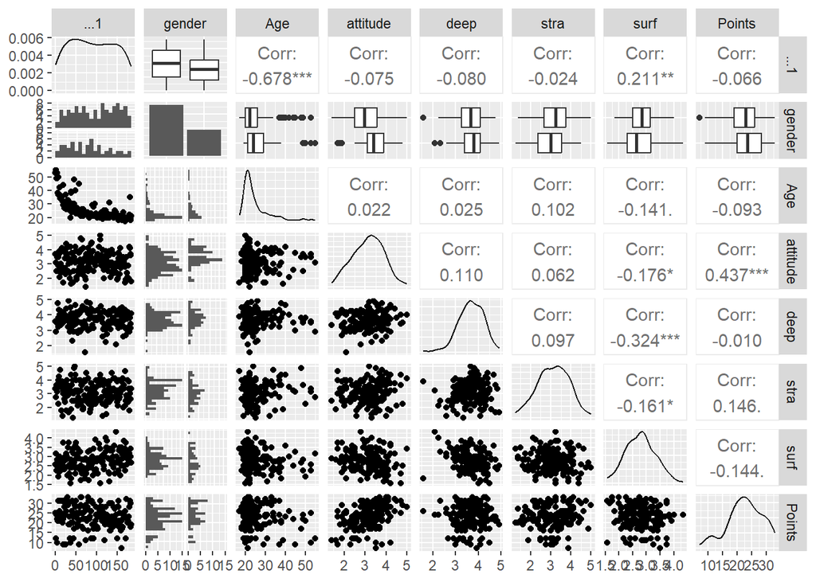

```r
ggpairs(learning2014, mapping = aes(), lower = list(combo = wrap("facethist", bins = 20)))
```

### Linear Regression

We attempt to use multiple linear regression to see what combination of variables has a significant effect on the variable “Points”. Therefore,, “Points” is the target variable in these models.

```r
# We create a regression model with the three learning approaches "stra", "surf" and "deep" as explanatory variables

a <- lm(Points~stra+surf+deep, data = learning2014)

# Summarising the model to help us decide weather the explanatory variables have a significant effect on Points.

summary (a)
```

```
##
## Call:
## lm(formula = Points ~ stra + surf + deep, data = learning2014)
##
## Residuals:
##      Min       1Q   Median       3Q      Max
## -15.1235  -3.0737   0.5226   4.2799  10.3229
##
## Coefficients:
##             Estimate Std. Error t value Pr(>|t|)
## (Intercept)  26.9143     5.1169   5.260  4.5e-07 ***
## stra          0.9878     0.5962   1.657   0.0994 .
## surf         -1.6296     0.9153  -1.780   0.0769 .
## deep         -0.7443     0.8662  -0.859   0.3915
## ---
## Signif. codes:  0 '***' 0.001 '**' 0.01 '*' 0.05 '.' 0.1 ' ' 1
##
## Residual standard error: 5.827 on 162 degrees of freedom
## Multiple R-squared:  0.04071,    Adjusted R-squared:  0.02295
## F-statistic: 2.292 on 3 and 162 DF,  p-value: 0.08016
```

1. *“deep”* does *not* have a *significant* relationship with “Points”
2. The *multiple R-squared* in 0.04, which means the model can only *explain about 4% of the data*.

We will try to replace the insignificant variable with another variable and see if it improves the model a bit. We will call this new model “b”.

```r
# Replacing "deep" with "attitude" as an explanatory variable

b <- lm(Points~stra+surf+attitude, data = learning2014)

# Summarising model "b" to help us decide weather the explanatory variables have a significant effect on Points.

summary (b)
```

```
##
## Call:
## lm(formula = Points ~ stra + surf + attitude, data = learning2014)
##
## Residuals:
##      Min       1Q   Median       3Q      Max
## -17.1550  -3.4346   0.5156   3.6401  10.8952
##
## Coefficients:
##             Estimate Std. Error t value Pr(>|t|)
## (Intercept)  11.0171     3.6837   2.991  0.00322 **
## stra          0.8531     0.5416   1.575  0.11716
## surf         -0.5861     0.8014  -0.731  0.46563
## attitude      3.3952     0.5741   5.913 1.93e-08 ***
## ---
## Signif. codes:  0 '***' 0.001 '**' 0.01 '*' 0.05 '.' 0.1 ' ' 1
##
## Residual standard error: 5.296 on 162 degrees of freedom
## Multiple R-squared:  0.2074, Adjusted R-squared:  0.1927
## F-statistic: 14.13 on 3 and 162 DF,  p-value: 3.156e-08
```

The variable “attitude” has a significant, direct relationship with our target variable. However, “stra” and “surf” do not.

```r
# Replacing variables again
c <- lm(Points~stra+deep+attitude, data = learning2014)

# Summarising model "b" to help us decide weather the explanatory variables have a significant effect on Points.

summary (c)
```

```
##
## Call:
## lm(formula = Points ~ stra + deep + attitude, data = learning2014)
##
## Residuals:
##      Min       1Q   Median       3Q      Max
## -17.5239  -3.4276   0.5474   3.8220  11.5112
##
## Coefficients:
##             Estimate Std. Error t value Pr(>|t|)
## (Intercept)  11.3915     3.4077   3.343  0.00103 **
## stra          0.9621     0.5367   1.793  0.07489 .
## deep         -0.7492     0.7507  -0.998  0.31974
## attitude      3.5254     0.5683   6.203 4.44e-09 ***
## ---
## Signif. codes:  0 '***' 0.001 '**' 0.01 '*' 0.05 '.' 0.1 ' ' 1
##
## Residual standard error: 5.289 on 162 degrees of freedom
## Multiple R-squared:  0.2097, Adjusted R-squared:  0.195
## F-statistic: 14.33 on 3 and 162 DF,  p-value: 2.521e-08
```

```r
# Replacing variables again
d <- lm(Points~stra+Age+attitude, data = learning2014)

# Summarising model "b" to help us decide weather the explanatory variables have a significant effect on Points.

summary (d)
```

```
##
## Call:
## lm(formula = Points ~ stra + Age + attitude, data = learning2014)
##
## Residuals:
##      Min       1Q   Median       3Q      Max
## -18.1149  -3.2003   0.3303   3.4129  10.7599
##
## Coefficients:
##             Estimate Std. Error t value Pr(>|t|)
## (Intercept) 10.89543    2.64834   4.114 6.17e-05 ***
## stra         1.00371    0.53434   1.878   0.0621 .
## Age         -0.08822    0.05302  -1.664   0.0981 .
## attitude     3.48077    0.56220   6.191 4.72e-09 ***
## ---
## Signif. codes:  0 '***' 0.001 '**' 0.01 '*' 0.05 '.' 0.1 ' ' 1
##
## Residual standard error: 5.26 on 162 degrees of freedom
## Multiple R-squared:  0.2182, Adjusted R-squared:  0.2037
## F-statistic: 15.07 on 3 and 162 DF,  p-value: 1.07e-08
```

The next section explains this model

### Explaining the model

Model “d” uses the variables “stra”, “Age” and “Attitude” to explain the variations in the target variable , “Points”.

##### **R-squared**

The multiple R-squared value of **0.2182** denotes that the model can accurately explain **21.82% of variations in points**, using the three explanatory variables.

### Validating the Model

The model’s validity will be tested using diagnostic plots using the plot() function.

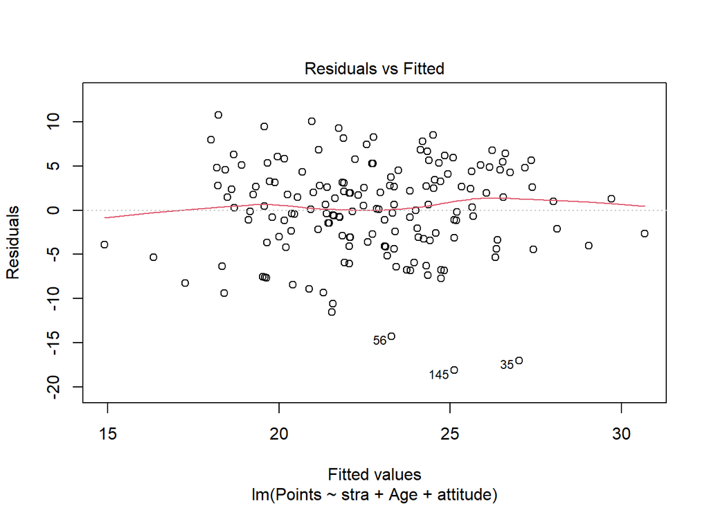

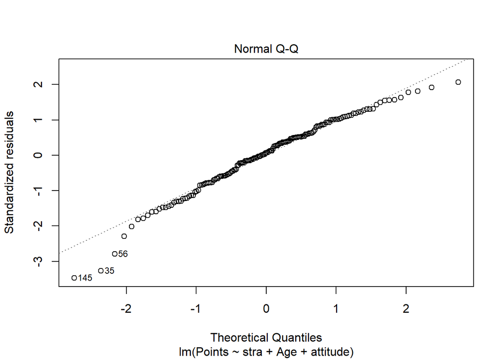

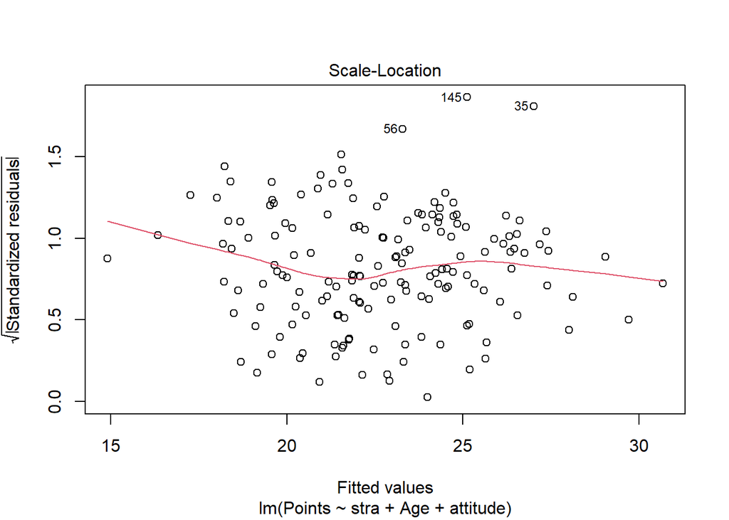

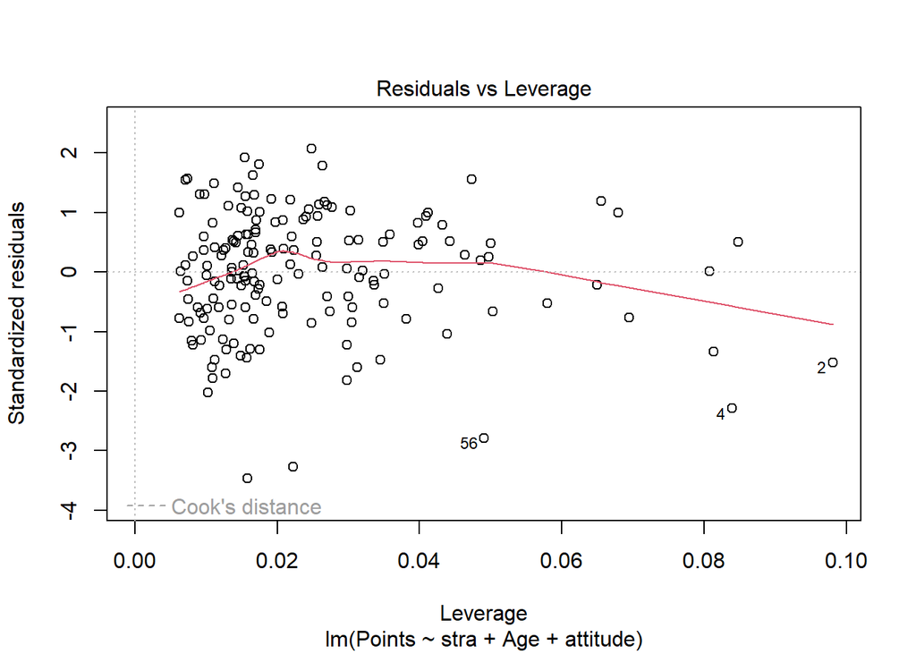

```r
# Producing diagnostic plots for the model "d"
plot(d)
```

##### **Residuals v/s Fitted**

- The residuals are distributed randomly and do not have any obvious patterns (although it also appears that more residuals fall above zero). On the whole, the plot indicates that the values deviate more or less randomly from the values predicted by the model.
  - This suggests that the relationship between the variables is more or less linear.
- There appear to be a few outliers (points 56, 145 and 35).

##### **Normal QQ-plot**

- Not all points coincide with the line, and there appear to be some negative residuals (those falling below the line). This suggests that the data may be skewed and not perfectly normally distributed.

##### **Residuals v/s Leverage**

- The lines indicating Cook’s distance are not visible in our Residuals v/s Leverage Plot. This indicates that all points fall within Cook’s distance. If any points had lied beyond Cook’s distance, they would be the most influential points in our data, removing which could potentially change the interpretation of the model. Therefore, we can assume that model “d” does not have any such points.